# Risk Factor Analysis

## Outcome Variable

**Outcome Variable:** sstunted

## Predictor Variables

**Intervention Variable:** gagebrth

**Adjustment Set:**

- arm
- sex
- W_mage
- meducyrs
- feducyrs
- hhwealth_quart
- W_nrooms
- W_nchldlt5
- brthmon
- W_parity
- impfloor
- impsan
- safeh20
- delta_W_mage
- delta_meducyrs
- delta_feducyrs
- delta_hhwealth_quart
- delta_W_nrooms
- delta_W_nchldlt5
- delta_brthmon
- delta_W_parity
- delta_impfloor
- delta_impsan
- delta_safeh20

## Stratifying Variables

The analysis was stratified on these variable(s):

- agecat
- studyid
- country

## Data Summary

| agecat | studyid | country | gagebrth | sstunted | n_cell | n |
| --- | --- | --- | --- | --- | --- | --- |
| Birth | ki1000108-CMC-V-BCS-2002 | INDIA | Full or late term | 0 | 54 | 90 |
| Birth | ki1000108-CMC-V-BCS-2002 | INDIA | Full or late term | 1 | 3 | 90 |
| Birth | ki1000108-CMC-V-BCS-2002 | INDIA | Preterm | 0 | 10 | 90 |
| Birth | ki1000108-CMC-V-BCS-2002 | INDIA | Preterm | 1 | 0 | 90 |
| Birth | ki1000108-CMC-V-BCS-2002 | INDIA | Early term | 0 | 23 | 90 |
| Birth | ki1000108-CMC-V-BCS-2002 | INDIA | Early term | 1 | 0 | 90 |
| Birth | ki1000108-IRC | INDIA | Full or late term | 0 | 228 | 369 |
| Birth | ki1000108-IRC | INDIA | Full or late term | 1 | 10 | 369 |
| Birth | ki1000108-IRC | INDIA | Preterm | 0 | 33 | 369 |
| Birth | ki1000108-IRC | INDIA | Preterm | 1 | 3 | 369 |
| Birth | ki1000108-IRC | INDIA | Early term | 0 | 93 | 369 |
| Birth | ki1000108-IRC | INDIA | Early term | 1 | 2 | 369 |
| Birth | ki1000109-EE | PAKISTAN | Full or late term | 0 | 0 | 4 |
| Birth | ki1000109-EE | PAKISTAN | Full or late term | 1 | 0 | 4 |
| Birth | ki1000109-EE | PAKISTAN | Preterm | 0 | 2 | 4 |
| Birth | ki1000109-EE | PAKISTAN | Preterm | 1 | 0 | 4 |
| Birth | ki1000109-EE | PAKISTAN | Early term | 0 | 2 | 4 |
| Birth | ki1000109-EE | PAKISTAN | Early term | 1 | 0 | 4 |
| Birth | ki1000304b-SAS-CompFeed | INDIA | Full or late term | 0 | 1 | 187 |
| Birth | ki1000304b-SAS-CompFeed | INDIA | Full or late term | 1 | 0 | 187 |
| Birth | ki1000304b-SAS-CompFeed | INDIA | Preterm | 0 | 161 | 187 |
| Birth | ki1000304b-SAS-CompFeed | INDIA | Preterm | 1 | 10 | 187 |
| Birth | ki1000304b-SAS-CompFeed | INDIA | Early term | 0 | 14 | 187 |
| Birth | ki1000304b-SAS-CompFeed | INDIA | Early term | 1 | 1 | 187 |
| Birth | ki1017093c-NIH-Crypto | BANGLADESH | Full or late term | 0 | 7 | 27 |
| Birth | ki1017093c-NIH-Crypto | BANGLADESH | Full or late term | 1 | 0 | 27 |
| Birth | ki1017093c-NIH-Crypto | BANGLADESH | Preterm | 0 | 5 | 27 |
| Birth | ki1017093c-NIH-Crypto | BANGLADESH | Preterm | 1 | 0 | 27 |
| Birth | ki1017093c-NIH-Crypto | BANGLADESH | Early term | 0 | 14 | 27 |
| Birth | ki1017093c-NIH-Crypto | BANGLADESH | Early term | 1 | 1 | 27 |

[output cut: 168 more lines]

The following strata were considered:

- agecat: 24 months, studyid: ki1000108-CMC-V-BCS-2002, country: INDIA
- agecat: 24 months, studyid: ki1000108-IRC, country: INDIA
- agecat: 24 months, studyid: ki1017093c-NIH-Crypto, country: BANGLADESH
- agecat: 24 months, studyid: ki1066203-TanzaniaChild2, country: TANZANIA, UNITED REPUBLIC OF
- agecat: 24 months, studyid: ki1101329-Keneba, country: GAMBIA
- agecat: 24 months, studyid: ki1119695-PROBIT, country: BELARUS
- agecat: 24 months, studyid: ki1135781-COHORTS, country: GUATEMALA
- agecat: 24 months, studyid: ki1135781-COHORTS, country: INDIA
- agecat: 24 months, studyid: ki1135781-COHORTS, country: PHILIPPINES
- agecat: 24 months, studyid: kiGH5241-JiVitA-3, country: BANGLADESH
- agecat: 6 months, studyid: ki1000108-CMC-V-BCS-2002, country: INDIA
- agecat: 6 months, studyid: ki1000108-IRC, country: INDIA
- agecat: 6 months, studyid: ki1000109-EE, country: PAKISTAN
- agecat: 6 months, studyid: ki1000304b-SAS-CompFeed, country: INDIA
- agecat: 6 months, studyid: ki1017093c-NIH-Crypto, country: BANGLADESH
- agecat: 6 months, studyid: ki1066203-TanzaniaChild2, country: TANZANIA, UNITED REPUBLIC OF
- agecat: 6 months, studyid: ki1101329-Keneba, country: GAMBIA
- agecat: 6 months, studyid: ki1119695-PROBIT, country: BELARUS
- agecat: 6 months, studyid: ki1135781-COHORTS, country: GUATEMALA
- agecat: 6 months, studyid: ki1135781-COHORTS, country: INDIA
- agecat: 6 months, studyid: ki1135781-COHORTS, country: PHILIPPINES
- agecat: 6 months, studyid: kiGH5241-JiVitA-3, country: BANGLADESH
- agecat: Birth, studyid: ki1000108-CMC-V-BCS-2002, country: INDIA
- agecat: Birth, studyid: ki1000108-IRC, country: INDIA
- agecat: Birth, studyid: ki1000109-EE, country: PAKISTAN
- agecat: Birth, studyid: ki1000304b-SAS-CompFeed, country: INDIA
- agecat: Birth, studyid: ki1017093c-NIH-Crypto, country: BANGLADESH
- agecat: Birth, studyid: ki1101329-Keneba, country: GAMBIA
- agecat: Birth, studyid: ki1119695-PROBIT, country: BELARUS
- agecat: Birth, studyid: ki1135781-COHORTS, country: GUATEMALA
- agecat: Birth, studyid: ki1135781-COHORTS, country: INDIA
- agecat: Birth, studyid: ki1135781-COHORTS, country: PHILIPPINES
- agecat: Birth, studyid: kiGH5241-JiVitA-3, country: BANGLADESH

### Dropped Strata

Some strata were dropped due to rare outcomes:

- agecat: Birth, studyid: ki1000108-CMC-V-BCS-2002, country: INDIA
- agecat: Birth, studyid: ki1000108-IRC, country: INDIA
- agecat: Birth, studyid: ki1000109-EE, country: PAKISTAN
- agecat: Birth, studyid: ki1000304b-SAS-CompFeed, country: INDIA
- agecat: Birth, studyid: ki1017093c-NIH-Crypto, country: BANGLADESH
- agecat: Birth, studyid: ki1119695-PROBIT, country: BELARUS
- agecat: Birth, studyid: ki1135781-COHORTS, country: GUATEMALA
- agecat: Birth, studyid: ki1135781-COHORTS, country: PHILIPPINES
- agecat: 6 months, studyid: ki1000108-IRC, country: INDIA
- agecat: 6 months, studyid: ki1000304b-SAS-CompFeed, country: INDIA
- agecat: 6 months, studyid: ki1017093c-NIH-Crypto, country: BANGLADESH
- agecat: 6 months, studyid: ki1066203-TanzaniaChild2, country: TANZANIA, UNITED REPUBLIC OF
- agecat: 6 months, studyid: ki1101329-Keneba, country: GAMBIA
- agecat: 24 months, studyid: ki1017093c-NIH-Crypto, country: BANGLADESH
- agecat: 24 months, studyid: ki1066203-TanzaniaChild2, country: TANZANIA, UNITED REPUBLIC OF

## Methods Detail

We’re interested in the causal parameters $E[Y_a]$ for all values of $a \in \mathcal{A}$. These parameters represent the mean outcome if, possibly contrary to fact, we intervened to set all units to have $A=a$. Under the randomization and positivity assumptions, these are identified by the statistical parameters $\psi_a=E_W[E_{Y|A,W}(Y|A=a,W)]$. In addition, we’re interested in the mean of $Y$, $E[Y]$ under no intervention (the observed mean). We will estimate these parameters by using SuperLearner to fit the relevant likelihood factors – $E_{Y|A,W}(Y|A=a,W)$ and $p(A=a|W)$, and then updating our likelihood fit using a joint TMLE.

For unadjusted analyses ($W=\{\}$), initial likelihoods were estimated using Lrnr_glm to estimate the simple $E(Y|A)$ and Lrnr_mean to estimate $p(A)$. For adjusted analyses, a small library containing Lrnr_glmnet, Lrnr_xgboost, and Lrnr_mean was used.

Having estimated these parameters, we will then use the delta method to estimate relative risks and attributable risks relative to a prespecified baseline level of $A$.

# Results Detail

## Results Plots

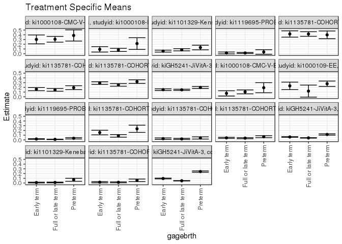

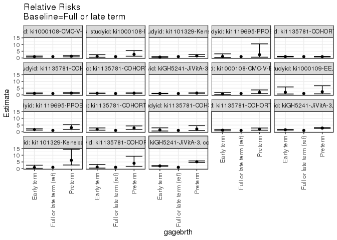

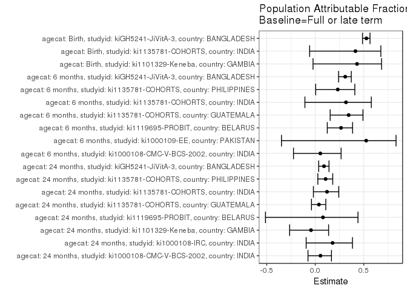

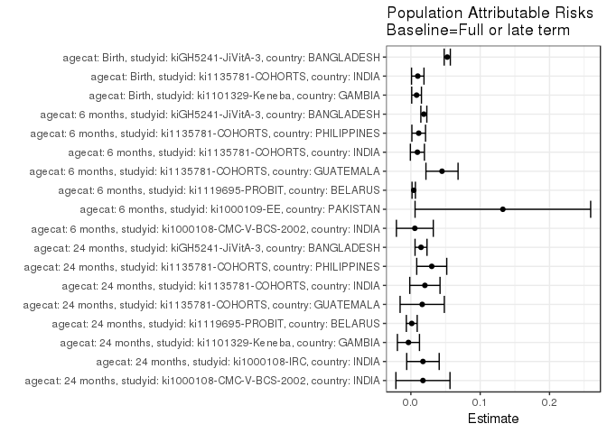

## Results Table

### Parameter: TSM

| agecat | studyid | country | intervention_level | baseline_level | estimate | ci_lower | ci_upper |
| --- | --- | --- | --- | --- | --- | --- | --- |
| Birth | ki1101329-Keneba | GAMBIA | Full or late term | NA | 0.0108992 | 0.0033854 | 0.0184130 |
| Birth | ki1101329-Keneba | GAMBIA | Preterm | NA | 0.0680851 | 0.0358691 | 0.1003011 |
| Birth | ki1101329-Keneba | GAMBIA | Early term | NA | 0.0091575 | 0.0011649 | 0.0171501 |
| Birth | ki1135781-COHORTS | INDIA | Full or late term | NA | 0.0140351 | 0.0043742 | 0.0236960 |
| Birth | ki1135781-COHORTS | INDIA | Preterm | NA | 0.0561404 | 0.0294051 | 0.0828756 |
| Birth | ki1135781-COHORTS | INDIA | Early term | NA | 0.0159817 | 0.0042330 | 0.0277305 |
| Birth | kiGH5241-JiVitA-3 | BANGLADESH | Full or late term | NA | 0.0470150 | 0.0425342 | 0.0514959 |
| Birth | kiGH5241-JiVitA-3 | BANGLADESH | Preterm | NA | 0.2422372 | 0.2287532 | 0.2557213 |
| Birth | kiGH5241-JiVitA-3 | BANGLADESH | Early term | NA | 0.0948235 | 0.0862837 | 0.1033633 |
| 6 months | ki1000108-CMC-V-BCS-2002 | INDIA | Full or late term | NA | 0.1037736 | 0.0626625 | 0.1448847 |
| 6 months | ki1000108-CMC-V-BCS-2002 | INDIA | Preterm | NA | 0.1923077 | 0.0850337 | 0.2995817 |
| 6 months | ki1000108-CMC-V-BCS-2002 | INDIA | Early term | NA | 0.0722892 | 0.0164963 | 0.1280820 |
| 6 months | ki1000109-EE | PAKISTAN | Full or late term | NA | 0.1200000 | -0.0075541 | 0.2475541 |
| 6 months | ki1000109-EE | PAKISTAN | Preterm | NA | 0.2761506 | 0.2193921 | 0.3329091 |
| 6 months | ki1000109-EE | PAKISTAN | Early term | NA | 0.2314815 | 0.1518278 | 0.3111352 |
| 6 months | ki1119695-PROBIT | BELARUS | Full or late term | NA | 0.0113185 | 0.0068242 | 0.0158127 |
| 6 months | ki1119695-PROBIT | BELARUS | Preterm | NA | 0.0343651 | 0.0197928 | 0.0489373 |
| 6 months | ki1119695-PROBIT | BELARUS | Early term | NA | 0.0186286 | 0.0111670 | 0.0260901 |
| 6 months | ki1135781-COHORTS | GUATEMALA | Full or late term | NA | 0.0855239 | 0.0579265 | 0.1131213 |
| 6 months | ki1135781-COHORTS | GUATEMALA | Preterm | NA | 0.2351483 | 0.1586556 | 0.3116409 |
| 6 months | ki1135781-COHORTS | GUATEMALA | Early term | NA | 0.1553500 | 0.1065820 | 0.2041180 |
| 6 months | ki1135781-COHORTS | INDIA | Full or late term | NA | 0.0203138 | 0.0085275 | 0.0321002 |
| 6 months | ki1135781-COHORTS | INDIA | Preterm | NA | 0.0413600 | 0.0184809 | 0.0642391 |
| 6 months | ki1135781-COHORTS | INDIA | Early term | NA | 0.0260654 | 0.0108086 | 0.0413223 |
| 6 months | ki1135781-COHORTS | PHILIPPINES | Full or late term | NA | 0.0374441 | 0.0257364 | 0.0491518 |
| 6 months | ki1135781-COHORTS | PHILIPPINES | Preterm | NA | 0.0671107 | 0.0461516 | 0.0880698 |
| 6 months | ki1135781-COHORTS | PHILIPPINES | Early term | NA | 0.0428123 | 0.0306949 | 0.0549298 |
| 6 months | kiGH5241-JiVitA-3 | BANGLADESH | Full or late term | NA | 0.0418590 | 0.0369450 | 0.0467729 |
| 6 months | kiGH5241-JiVitA-3 | BANGLADESH | Preterm | NA | 0.1149452 | 0.1019032 | 0.1279872 |
| 6 months | kiGH5241-JiVitA-3 | BANGLADESH | Early term | NA | 0.0614444 | 0.0531735 | 0.0697153 |
| 24 months | ki1000108-CMC-V-BCS-2002 | INDIA | Full or late term | NA | 0.3054247 | 0.2442769 | 0.3665725 |
| 24 months | ki1000108-CMC-V-BCS-2002 | INDIA | Preterm | NA | 0.3863430 | 0.2678812 | 0.5048049 |
| 24 months | ki1000108-CMC-V-BCS-2002 | INDIA | Early term | NA | 0.3020892 | 0.2074745 | 0.3967039 |
| 24 months | ki1000108-IRC | INDIA | Full or late term | NA | 0.0800000 | 0.0463276 | 0.1136724 |
| 24 months | ki1000108-IRC | INDIA | Preterm | NA | 0.2142857 | 0.0900319 | 0.3385396 |
| 24 months | ki1000108-IRC | INDIA | Early term | NA | 0.0918367 | 0.0345858 | 0.1490877 |
| 24 months | ki1101329-Keneba | GAMBIA | Full or late term | NA | 0.0830828 | 0.0600860 | 0.1060796 |
| 24 months | ki1101329-Keneba | GAMBIA | Preterm | NA | 0.1308133 | 0.0820168 | 0.1796098 |
| 24 months | ki1101329-Keneba | GAMBIA | Early term | NA | 0.0543973 | 0.0335675 | 0.0752272 |
| 24 months | ki1119695-PROBIT | BELARUS | Full or late term | NA | 0.0148221 | 0.0038188 | 0.0258255 |
| 24 months | ki1119695-PROBIT | BELARUS | Preterm | NA | 0.0364964 | -0.0116126 | 0.0846053 |
| 24 months | ki1119695-PROBIT | BELARUS | Early term | NA | 0.0160085 | -0.0030877 | 0.0351047 |
| 24 months | ki1135781-COHORTS | GUATEMALA | Full or late term | NA | 0.4165231 | 0.3678865 | 0.4651598 |
| 24 months | ki1135781-COHORTS | GUATEMALA | Preterm | NA | 0.3987725 | 0.3172549 | 0.4802901 |
| 24 months | ki1135781-COHORTS | GUATEMALA | Early term | NA | 0.4172252 | 0.3507272 | 0.4837231 |
| 24 months | ki1135781-COHORTS | INDIA | Full or late term | NA | 0.1464314 | 0.1182918 | 0.1745711 |
| 24 months | ki1135781-COHORTS | INDIA | Preterm | NA | 0.1926502 | 0.1511866 | 0.2341139 |
| 24 months | ki1135781-COHORTS | INDIA | Early term | NA | 0.1617180 | 0.1286412 | 0.1947947 |
| 24 months | ki1135781-COHORTS | PHILIPPINES | Full or late term | NA | 0.2516596 | 0.2242862 | 0.2790330 |
| 24 months | ki1135781-COHORTS | PHILIPPINES | Preterm | NA | 0.3206547 | 0.2815737 | 0.3597357 |
| 24 months | ki1135781-COHORTS | PHILIPPINES | Early term | NA | 0.2906116 | 0.2627238 | 0.3184994 |
| 24 months | kiGH5241-JiVitA-3 | BANGLADESH | Full or late term | NA | 0.1476448 | 0.1344676 | 0.1608220 |
| 24 months | kiGH5241-JiVitA-3 | BANGLADESH | Preterm | NA | 0.1968003 | 0.1757677 | 0.2178328 |
| 24 months | kiGH5241-JiVitA-3 | BANGLADESH | Early term | NA | 0.1510630 | 0.1327618 | 0.1693641 |

### Parameter: E(Y)

| agecat | studyid | country | intervention_level | baseline_level | estimate | ci_lower | ci_upper |
| --- | --- | --- | --- | --- | --- | --- | --- |
| Birth | ki1101329-Keneba | GAMBIA | NA | NA | 0.0191419 | 0.0122398 | 0.0260440 |
| Birth | ki1135781-COHORTS | INDIA | NA | NA | 0.0239753 | 0.0156340 | 0.0323165 |
| Birth | kiGH5241-JiVitA-3 | BANGLADESH | NA | NA | 0.0994901 | 0.0949359 | 0.1040443 |
| 6 months | ki1000108-CMC-V-BCS-2002 | INDIA | NA | NA | 0.1095101 | 0.0766059 | 0.1424143 |
| 6 months | ki1000109-EE | PAKISTAN | NA | NA | 0.2526882 | 0.2084696 | 0.2969067 |
| 6 months | ki1119695-PROBIT | BELARUS | NA | NA | 0.0154178 | 0.0100323 | 0.0208033 |
| 6 months | ki1135781-COHORTS | GUATEMALA | NA | NA | 0.1304348 | 0.1056973 | 0.1551723 |
| 6 months | ki1135781-COHORTS | INDIA | NA | NA | 0.0297256 | 0.0205326 | 0.0389187 |
| 6 months | ki1135781-COHORTS | PHILIPPINES | NA | NA | 0.0487533 | 0.0406091 | 0.0568974 |
| 6 months | kiGH5241-JiVitA-3 | BANGLADESH | NA | NA | 0.0605721 | 0.0559673 | 0.0651769 |
| 24 months | ki1000108-CMC-V-BCS-2002 | INDIA | NA | NA | 0.3228571 | 0.2738024 | 0.3719119 |
| 24 months | ki1000108-IRC | INDIA | NA | NA | 0.0974359 | 0.0679665 | 0.1269053 |
| 24 months | ki1101329-Keneba | GAMBIA | NA | NA | 0.0795848 | 0.0639762 | 0.0951934 |
| 24 months | ki1119695-PROBIT | BELARUS | NA | NA | 0.0161090 | 0.0034156 | 0.0288025 |
| 24 months | ki1135781-COHORTS | GUATEMALA | NA | NA | 0.4328808 | 0.3951375 | 0.4706242 |
| 24 months | ki1135781-COHORTS | INDIA | NA | NA | 0.1666667 | 0.1464624 | 0.1868710 |
| 24 months | ki1135781-COHORTS | PHILIPPINES | NA | NA | 0.2817657 | 0.2638535 | 0.2996779 |
| 24 months | kiGH5241-JiVitA-3 | BANGLADESH | NA | NA | 0.1622891 | 0.1518212 | 0.1727571 |

### Parameter: RR

| agecat | studyid | country | intervention_level | baseline_level | estimate | ci_lower | ci_upper |
| --- | --- | --- | --- | --- | --- | --- | --- |
| Birth | ki1101329-Keneba | GAMBIA | Full or late term | Full or late term | 1.0000000 | 1.0000000 | 1.000000 |
| Birth | ki1101329-Keneba | GAMBIA | Preterm | Full or late term | 6.2468085 | 2.7072028 | 14.414368 |
| Birth | ki1101329-Keneba | GAMBIA | Early term | Full or late term | 0.8402015 | 0.2762834 | 2.555125 |
| Birth | ki1135781-COHORTS | INDIA | Full or late term | Full or late term | 1.0000000 | 1.0000000 | 1.000000 |
| Birth | ki1135781-COHORTS | INDIA | Preterm | Full or late term | 4.0000000 | 1.7320013 | 9.237869 |
| Birth | ki1135781-COHORTS | INDIA | Early term | Full or late term | 1.1386986 | 0.4159430 | 3.117338 |
| Birth | kiGH5241-JiVitA-3 | BANGLADESH | Full or late term | Full or late term | 1.0000000 | 1.0000000 | 1.000000 |
| Birth | kiGH5241-JiVitA-3 | BANGLADESH | Preterm | Full or late term | 5.1523362 | 4.6037313 | 5.766316 |
| Birth | kiGH5241-JiVitA-3 | BANGLADESH | Early term | Full or late term | 2.0168757 | 1.7737677 | 2.293303 |
| 6 months | ki1000108-CMC-V-BCS-2002 | INDIA | Full or late term | Full or late term | 1.0000000 | 1.0000000 | 1.000000 |
| 6 months | ki1000108-CMC-V-BCS-2002 | INDIA | Preterm | Full or late term | 1.8531469 | 0.9349126 | 3.673234 |
| 6 months | ki1000108-CMC-V-BCS-2002 | INDIA | Early term | Full or late term | 0.6966046 | 0.2925632 | 1.658643 |
| 6 months | ki1000109-EE | PAKISTAN | Full or late term | Full or late term | 1.0000000 | 1.0000000 | 1.000000 |
| 6 months | ki1000109-EE | PAKISTAN | Preterm | Full or late term | 2.3012552 | 0.7794355 | 6.794373 |
| 6 months | ki1000109-EE | PAKISTAN | Early term | Full or late term | 1.9290123 | 0.6311239 | 5.895972 |
| 6 months | ki1119695-PROBIT | BELARUS | Full or late term | Full or late term | 1.0000000 | 1.0000000 | 1.000000 |
| 6 months | ki1119695-PROBIT | BELARUS | Preterm | Full or late term | 3.0361979 | 1.7484937 | 5.272251 |
| 6 months | ki1119695-PROBIT | BELARUS | Early term | Full or late term | 1.6458573 | 1.2227327 | 2.215404 |
| 6 months | ki1135781-COHORTS | GUATEMALA | Full or late term | Full or late term | 1.0000000 | 1.0000000 | 1.000000 |
| 6 months | ki1135781-COHORTS | GUATEMALA | Preterm | Full or late term | 2.7495030 | 1.7397992 | 4.345195 |
| 6 months | ki1135781-COHORTS | GUATEMALA | Early term | Full or late term | 1.8164513 | 1.1587865 | 2.847371 |
| 6 months | ki1135781-COHORTS | INDIA | Full or late term | Full or late term | 1.0000000 | 1.0000000 | 1.000000 |
| 6 months | ki1135781-COHORTS | INDIA | Preterm | Full or late term | 2.0360515 | 0.9150511 | 4.530354 |
| 6 months | ki1135781-COHORTS | INDIA | Early term | Full or late term | 1.2831364 | 0.5631251 | 2.923754 |
| 6 months | ki1135781-COHORTS | PHILIPPINES | Full or late term | Full or late term | 1.0000000 | 1.0000000 | 1.000000 |
| 6 months | ki1135781-COHORTS | PHILIPPINES | Preterm | Full or late term | 1.7922899 | 1.1530188 | 2.785994 |
| 6 months | ki1135781-COHORTS | PHILIPPINES | Early term | Full or late term | 1.1433671 | 0.7505351 | 1.741809 |
| 6 months | kiGH5241-JiVitA-3 | BANGLADESH | Full or late term | Full or late term | 1.0000000 | 1.0000000 | 1.000000 |
| 6 months | kiGH5241-JiVitA-3 | BANGLADESH | Preterm | Full or late term | 2.7460114 | 2.3456844 | 3.214660 |
| 6 months | kiGH5241-JiVitA-3 | BANGLADESH | Early term | Full or late term | 1.4678913 | 1.2269466 | 1.756152 |
| 24 months | ki1000108-CMC-V-BCS-2002 | INDIA | Full or late term | Full or late term | 1.0000000 | 1.0000000 | 1.000000 |
| 24 months | ki1000108-CMC-V-BCS-2002 | INDIA | Preterm | Full or late term | 1.2649370 | 0.8768486 | 1.824791 |
| 24 months | ki1000108-CMC-V-BCS-2002 | INDIA | Early term | Full or late term | 0.9890790 | 0.6820717 | 1.434273 |
| 24 months | ki1000108-IRC | INDIA | Full or late term | Full or late term | 1.0000000 | 1.0000000 | 1.000000 |
| 24 months | ki1000108-IRC | INDIA | Preterm | Full or late term | 2.6785714 | 1.3083567 | 5.483783 |
| 24 months | ki1000108-IRC | INDIA | Early term | Full or late term | 1.1479592 | 0.5410719 | 2.435555 |
| 24 months | ki1101329-Keneba | GAMBIA | Full or late term | Full or late term | 1.0000000 | 1.0000000 | 1.000000 |
| 24 months | ki1101329-Keneba | GAMBIA | Preterm | Full or late term | 1.5744937 | 0.9920332 | 2.498939 |
| 24 months | ki1101329-Keneba | GAMBIA | Early term | Full or late term | 0.6547366 | 0.4092794 | 1.047402 |
| 24 months | ki1119695-PROBIT | BELARUS | Full or late term | Full or late term | 1.0000000 | 1.0000000 | 1.000000 |
| 24 months | ki1119695-PROBIT | BELARUS | Preterm | Full or late term | 2.4622871 | 0.5762612 | 10.521023 |
| 24 months | ki1119695-PROBIT | BELARUS | Early term | Full or late term | 1.0800427 | 0.3773256 | 3.091474 |
| 24 months | ki1135781-COHORTS | GUATEMALA | Full or late term | Full or late term | 1.0000000 | 1.0000000 | 1.000000 |
| 24 months | ki1135781-COHORTS | GUATEMALA | Preterm | Full or late term | 0.9573838 | 0.7578717 | 1.209418 |
| 24 months | ki1135781-COHORTS | GUATEMALA | Early term | Full or late term | 1.0016855 | 0.8236193 | 1.218249 |
| 24 months | ki1135781-COHORTS | INDIA | Full or late term | Full or late term | 1.0000000 | 1.0000000 | 1.000000 |
| 24 months | ki1135781-COHORTS | INDIA | Preterm | Full or late term | 1.3156345 | 0.9890713 | 1.750020 |
| 24 months | ki1135781-COHORTS | INDIA | Early term | Full or late term | 1.1043938 | 0.8367881 | 1.457580 |
| 24 months | ki1135781-COHORTS | PHILIPPINES | Full or late term | Full or late term | 1.0000000 | 1.0000000 | 1.000000 |
| 24 months | ki1135781-COHORTS | PHILIPPINES | Preterm | Full or late term | 1.2741603 | 1.0836837 | 1.498117 |
| 24 months | ki1135781-COHORTS | PHILIPPINES | Early term | Full or late term | 1.1547805 | 1.0003903 | 1.332998 |
| 24 months | kiGH5241-JiVitA-3 | BANGLADESH | Full or late term | Full or late term | 1.0000000 | 1.0000000 | 1.000000 |
| 24 months | kiGH5241-JiVitA-3 | BANGLADESH | Preterm | Full or late term | 1.3329308 | 1.1652344 | 1.524762 |
| 24 months | kiGH5241-JiVitA-3 | BANGLADESH | Early term | Full or late term | 1.0231514 | 0.8871640 | 1.179983 |

### Parameter: PAR

| agecat | studyid | country | intervention_level | baseline_level | estimate | ci_lower | ci_upper |
| --- | --- | --- | --- | --- | --- | --- | --- |
| Birth | ki1101329-Keneba | GAMBIA | Full or late term | NA | 0.0082427 | 0.0012149 | 0.0152706 |
| Birth | ki1135781-COHORTS | INDIA | Full or late term | NA | 0.0099402 | 0.0009613 | 0.0189190 |
| Birth | kiGH5241-JiVitA-3 | BANGLADESH | Full or late term | NA | 0.0524750 | 0.0480330 | 0.0569171 |
| 6 months | ki1000108-CMC-V-BCS-2002 | INDIA | Full or late term | NA | 0.0057365 | -0.0208651 | 0.0323381 |
| 6 months | ki1000109-EE | PAKISTAN | Full or late term | NA | 0.1326882 | 0.0060450 | 0.2593314 |
| 6 months | ki1119695-PROBIT | BELARUS | Full or late term | NA | 0.0040994 | 0.0016839 | 0.0065148 |
| 6 months | ki1135781-COHORTS | GUATEMALA | Full or late term | NA | 0.0449109 | 0.0217470 | 0.0680748 |
| 6 months | ki1135781-COHORTS | INDIA | Full or late term | NA | 0.0094118 | -0.0007164 | 0.0195400 |
| 6 months | ki1135781-COHORTS | PHILIPPINES | Full or late term | NA | 0.0113092 | 0.0014518 | 0.0211665 |
| 6 months | kiGH5241-JiVitA-3 | BANGLADESH | Full or late term | NA | 0.0187131 | 0.0144022 | 0.0230240 |
| 24 months | ki1000108-CMC-V-BCS-2002 | INDIA | Full or late term | NA | 0.0174324 | -0.0215660 | 0.0564309 |
| 24 months | ki1000108-IRC | INDIA | Full or late term | NA | 0.0174359 | -0.0059874 | 0.0408591 |
| 24 months | ki1101329-Keneba | GAMBIA | Full or late term | NA | -0.0034980 | -0.0194209 | 0.0124248 |
| 24 months | ki1119695-PROBIT | BELARUS | Full or late term | NA | 0.0012869 | -0.0065493 | 0.0091231 |
| 24 months | ki1135781-COHORTS | GUATEMALA | Full or late term | NA | 0.0163577 | -0.0155308 | 0.0482463 |
| 24 months | ki1135781-COHORTS | INDIA | Full or late term | NA | 0.0202352 | -0.0015914 | 0.0420619 |
| 24 months | ki1135781-COHORTS | PHILIPPINES | Full or late term | NA | 0.0301061 | 0.0084570 | 0.0517551 |
| 24 months | kiGH5241-JiVitA-3 | BANGLADESH | Full or late term | NA | 0.0146444 | 0.0060179 | 0.0232708 |

### Parameter: PAF

| agecat | studyid | country | intervention_level | baseline_level | estimate | ci_lower | ci_upper |
| --- | --- | --- | --- | --- | --- | --- | --- |
| Birth | ki1101329-Keneba | GAMBIA | Full or late term | NA | 0.4306117 | -0.0227788 | 0.6830174 |
| Birth | ki1135781-COHORTS | INDIA | Full or late term | NA | 0.4146010 | -0.0580236 | 0.6761018 |
| Birth | kiGH5241-JiVitA-3 | BANGLADESH | Full or late term | NA | 0.5274400 | 0.4872242 | 0.5645017 |
| 6 months | ki1000108-CMC-V-BCS-2002 | INDIA | Full or late term | NA | 0.0523833 | -0.2240006 | 0.2663587 |
| 6 months | ki1000109-EE | PAKISTAN | Full or late term | NA | 0.5251064 | -0.3479495 | 0.8326911 |
| 6 months | ki1119695-PROBIT | BELARUS | Full or late term | NA | 0.2658842 | 0.1241419 | 0.3846880 |
| 6 months | ki1135781-COHORTS | GUATEMALA | Full or late term | NA | 0.3443167 | 0.1538009 | 0.4919391 |
| 6 months | ki1135781-COHORTS | INDIA | Full or late term | NA | 0.3166217 | -0.1064084 | 0.5779082 |
| 6 months | ki1135781-COHORTS | PHILIPPINES | Full or late term | NA | 0.2319675 | 0.0041505 | 0.4076675 |
| 6 months | kiGH5241-JiVitA-3 | BANGLADESH | Full or late term | NA | 0.3089396 | 0.2401562 | 0.3714964 |
| 24 months | ki1000108-CMC-V-BCS-2002 | INDIA | Full or late term | NA | 0.0539942 | -0.0747062 | 0.1672822 |
| 24 months | ki1000108-IRC | INDIA | Full or late term | NA | 0.1789474 | -0.0935755 | 0.3835566 |
| 24 months | ki1101329-Keneba | GAMBIA | Full or late term | NA | -0.0439534 | -0.2640445 | 0.1378162 |
| 24 months | ki1119695-PROBIT | BELARUS | Full or late term | NA | 0.0798875 | -0.5128990 | 0.4404074 |
| 24 months | ki1135781-COHORTS | GUATEMALA | Full or late term | NA | 0.0377880 | -0.0387385 | 0.1086766 |
| 24 months | ki1135781-COHORTS | INDIA | Full or late term | NA | 0.1214114 | -0.0189731 | 0.2424551 |
| 24 months | ki1135781-COHORTS | PHILIPPINES | Full or late term | NA | 0.1068479 | 0.0266695 | 0.1804216 |
| 24 months | kiGH5241-JiVitA-3 | BANGLADESH | Full or late term | NA | 0.0902362 | 0.0355140 | 0.1418536 |